# Introduction to model assisted estimation

## Model assisted estimation

- Sometimes we have **auxiliary information** available, ie. information \(x\) known for both the sampled units but **also** at the population level \(\tau_x\)
- Trivial example: Export is a fixed ratio of the turnover \[ \hat{\tau}_y^{ratio} = \frac{\tau_x}{\hat{\tau}_x^{HT}}\hat{\tau}_y^{HT} \]

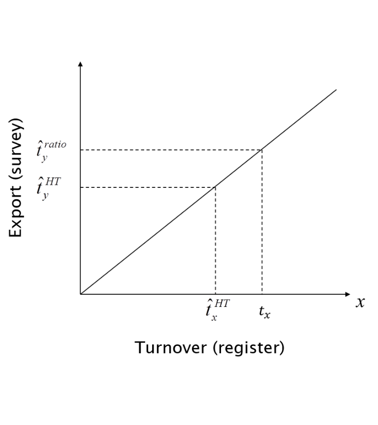

## The regression estimate

- The purpose of the regression estimate is to use an **auxiliary variable** \(x\) to get a better estimate of our **variable of interest** \(y\)
- **Better** means either
  - smaller standard error
  - or reduction of bias
- One can show that the regression etimate may be though of as an **adjusted** HT-estimate:

\[ \hat{\tau}_y^{GREG} = \hat{\tau}_y^{HT} + (\tau_x - \hat{\tau}_x)\hat{\beta} \]

- Assume we know the **totals** of the auxiliary variable at the **population level** \[ \tau_x = \sum_{i \in \mathcal{U}}x_i \]
- We **could** also estimate these quantities from the sample applying the HT-estimator \[ \hat{\tau}_x^{HT}=\sum_{i \in \mathcal{S}}d_i x_i \] where \(d_i\) is the design weight for sample unit \(i\), ie. \(\pi _i^{-1}\)
- Hopefully \(\hat{\tau}_x^{HT} \approx \tau_x\) but generally the two quantities will not be exactly equal
- In principle, this is unimportant, since we already know the true value
- But since the design weight \(d\) is also used for estimating totals for our variables of interest \(y\), we must expect these to be a little off, too – especially if \(y\) and \(x\) are correlated
- Hence, we seek a **calibrated weight** \(w_i\) such that the following calibration equation is satisfied \[ \sum_{i \in \mathcal{S}} w_i x_i = \tau_x \]
- The calibrated weights should ideally be close to the original design weights, so the calibrated weights are found as the solution to a **minimization** problem: \[ \min \sum_{i \in \mathcal{S}} G(w_i,d_i) \quad \textrm{subject to} \quad \sum_{i \in \mathcal{S}} w_i x_i = \tau_x \]
- \(G\) is a function measuring the distance between the design weight and the calibrated weight – for the regression estimate we use a quadratic distance function \[ G(w,d) = \frac{(w-d)^2}{2d} \]
- Now the regression estimate for our variable of interest \(y\) can simply be calculated as a weighted sum \[ \hat{\tau}_y^{GREG} = \sum_{i \in \mathcal{S}} w_i y_i \]
- The calibrated weight can be regarded as the design weight \(d\) multiplied with a \(g\)-weight (a factor introducing individual corrections) \[ w_i = g_i d_i \Rightarrow g_i = \frac{w_i}{d_i} \]
- Always check the \(g\)-weights – if there are **extreme values** check again what you are trying to accomplish with the calibration equations
- A third (and final) interpretation of the GREG-estimate (giving more prominence to an underlying linear model) is as the sum of predicted (or fitted) values for the entire population **plus** the design weighted residuals \[ \hat{\tau}_y^{GREG} = \sum_{i \in \mathcal{U}} \hat{y}_i + \sum_{i \in \mathcal{S}} d_i (y_i - \hat{y}_i) \]
- Calculating \(V(\hat{\tau}_y^{GREG})\) involves approximation by Taylor expansion and is generally best left to some suitable package in R…

## The regression estimate with R

- We create a small (\(N=10\)) and very simple population with two variables and no strata
- Variable \(x\) is an auxiliary variable available from a register (say land area measured in hectare), while \(y\) is our main variable of interest only available from a sample (say crop production measured in ton)

```r
my.pop <- data.frame(id=1:10,
                      x=c(99,111,114,95,110,102,94,83,96,102),
                      y=c(647,654,674,637,664,653,644,625,654,647))
```

- There is a strong positive correlation between \(x\) and \(y\) (\(\rho =\) 0.9032489)

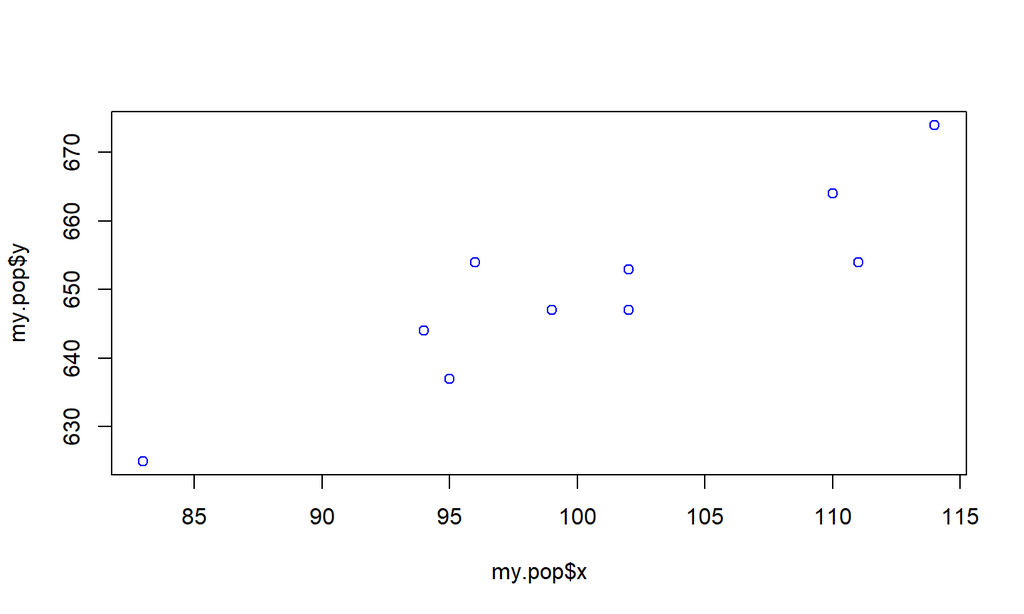

- Now we draw a simple random sample (SRS) of size 3 and estimate both \(\tau_x\) and \(\tau_y\) using the `survey` package:

```r
s <- c(1,3,8)
my.sample <- my.pop[s,]
my.sample$N <- nrow(my.pop)

library(survey)
srs.svyobj <- svydesign(ids = ~1,
                       fpc = ~N,
                       data = my.sample)
```

```r
(y.hat <- svytotal (~y, srs.svyobj))
```

```
##    total     SE
## y 6486.7 118.55
```

```r
(x.hat <- svytotal (~x, srs.svyobj))
```

```
##    total     SE
## x 986.67 74.885
```

```r
sum(my.pop$x)
```

```
## [1] 1006
```

- We now turn to calibration (the regression estimate) and start by setting up a target consisting of the known population size and the known total of \(x\)

```r
(cgoal <- c('(Intercept)'=nrow(my.pop), 'x'=sum(my.pop$x)))
```

```
## (Intercept)           x
##          10        1006
```

- Don’t worry too much about using named vectors – it is just syntax…
- The calibration is done by an aptly named function

```r
cal.svyobj <- calibrate (srs.svyobj,
                         formula=~x,
                         population=cgoal)
```

- We use the new survey object to calculate a regression estimate of \(\tau_x\), although the result is known by definition in advance

```r
(x.hat.cal <- svytotal (~x, cal.svyobj))
```

```
##   total SE
## x  1006  0
```

- More interesting, we calculate the regression estimate of \(y\)

```r
(y.hat.cal <- svytotal (~y, cal.svyobj))
```

```
##    total     SE
## y 6517.2 9.2829
```

- Remember that the true (but principally unknown) value of \(\tau_y\) is 6499 – in this case the power from the correlation between \(x\) and \(y\) is used to reduce the standard error rather than the bias
- We can get the calibrated weight (and also the \(g\)-weights) to gain some insight

```r
my.sample$dw <- nrow(my.pop) / nrow(my.sample)
my.sample$cw <- weights(cal.svyobj)
my.sample$gw <- my.sample$cw / my.sample$dw
```

```r
my.sample
```

```
##   id   x   y  N       dw       cw       gw
## 1  1  99 647 10 3.333333 3.346741 1.004022
## 3  3 114 674 10 3.333333 3.950069 1.185021
## 8  8  83 625 10 3.333333 2.703190 0.810957
```

- \(\tau_x\) was estimated slightly smaller than the target value with the HT-estimator – therefore \(g>1\) for the largest unit (in terms of \(x\)) while \(g<1\) for the smallest unit
- Also note the following proporties

```r
sum(my.sample$dw)
```

```
## [1] 10
```

```r
sum(my.sample$cw)
```

```
## [1] 10
```

```r
mean(my.sample$gw)
```

```
## [1] 1
```

- Now imagine that an updated frame population shows that the true number of units is 12 rather than 10, and that the true total value of x is 1100 hectares rather than 1006
- Adjusting the target to these figures allows us to raise the sample to the level of the updated frame population

```r
cgoal.new <- c('(Intercept)'=12,'x'=1100)

cal.svyobj.new <- calibrate (srs.svyobj, formula=~x,
                   population=cgoal.new)
(x.hat.cal.new <- svytotal (~x, cal.svyobj.new))
```

```
##   total SE
## x  1100  0
```

```r
(y.hat.cal.new <- svytotal (~y, cal.svyobj.new))
```

```
##    total     SE
## y 7651.4 11.595
```

```r
cv(y.hat.cal.new)
```

```
##             y
## y 0.001515457
```

- The result of using the target from the updated frame population that the estimate of \(\tau_y\) has been increased significantly
- Notice also that the CV is also higher –- raising the estimates relative to the original frame comes at a cost
- Finally we may derive and inspect the new correction weights.

[output not shown]

```r
sum(my.sample$cw2)
```

```
## [1] 12
```

```r
mean(my.sample$gw2)
```

```
## [1] 1.2
```